# Creditninja final report

Ye

3/1/2020

# Loading files and Packages

## R Packages Used

```r
library(Hmisc)# Description of the data
library(dplyr)
library(tidyverse)
library(tidytext)
library(ggplot2)
library(plyr)
library(ggpubr)
library(rpart) # Decision tree model
library(rpart.plot) # Decision tree plots
library(caret)
```

## Importing the dataset

```r
raw <- read.csv("raw_data.csv", header=TRUE, sep= ",", strip.white=TRUE,col.names= c("age", "workclass", "fnlwgt", "education", "educationnum", "maritalstatus", "occupation","relationship", "race", "sex", "capitalgain",
 "capitalloss", "hoursperweek", "nativecountry",
"income"), na.strings= "?", stringsAsFactors = TRUE)

head(raw)
```

```
##   age        workclass fnlwgt education educationnum      maritalstatus
## 1  39        State-gov  77516 Bachelors           13      Never-married
## 2  50 Self-emp-not-inc  83311 Bachelors           13 Married-civ-spouse
## 3  38          Private 215646   HS-grad            9           Divorced
## 4  53          Private 234721      11th            7 Married-civ-spouse
## 5  28          Private 338409 Bachelors           13 Married-civ-spouse
## 6  37          Private 284582   Masters           14 Married-civ-spouse
##          occupation  relationship  race    sex capitalgain capitalloss
## 1      Adm-clerical Not-in-family White   Male        2174           0
## 2   Exec-managerial       Husband White   Male           0           0
## 3 Handlers-cleaners Not-in-family White   Male           0           0
## 4 Handlers-cleaners       Husband Black   Male           0           0
## 5    Prof-specialty          Wife Black Female           0           0
## 6   Exec-managerial          Wife White Female           0           0
##   hoursperweek nativecountry income
## 1           40 United-States  <=50K
## 2           13 United-States  <=50K
## 3           40 United-States  <=50K
## 4           40 United-States  <=50K
## 5           40          Cuba  <=50K
## 6           40 United-States  <=50K
```

# Question 1

Which race, sex combination is most represented in this data set? Which race, sex combination is least likely to make more than $50K?

```r
Q1_1 <- data.frame(ddply(raw,.(race,sex),nrow))

Q1_1$race_sex_combine <- paste(Q1_1$race,Q1_1$sex)
Q1_1 <- Q1_1%>%
  mutate(num_rows = V1)%>%
  select(race_sex_combine,num_rows)%>%
  arrange(desc(num_rows))
Q1_1
```

```
##             race_sex_combine num_rows
## 1                 White Male    19174
## 2               White Female     8642
## 3                 Black Male     1569
## 4               Black Female     1555
## 5    Asian-Pac-Islander Male      693
## 6  Asian-Pac-Islander Female      346
## 7    Amer-Indian-Eskimo Male      192
## 8                 Other Male      162
## 9  Amer-Indian-Eskimo Female      119
## 10              Other Female      109
```

From the table, white male combination has the most rows, followed by white femail and black male.

```r
Q1_2 <- data.frame(ddply(raw,.(race,sex,income),nrow))

Q1_2$race_sex_combine <- paste(Q1_2$race,Q1_2$sex)

Q1_2 <- Q1_2%>%
  mutate(num_rows = V1)%>%
  select(race_sex_combine,income,num_rows)%>%
  arrange(num_rows)
Q1_2
```

```
##             race_sex_combine income num_rows
## 1               Other Female   >50K        6
## 2  Amer-Indian-Eskimo Female   >50K       12
## 3                 Other Male   >50K       19
## 4    Amer-Indian-Eskimo Male   >50K       24
## 5  Asian-Pac-Islander Female   >50K       43
## 6               Black Female   >50K       90
## 7               Other Female  <=50K      103
## 8  Amer-Indian-Eskimo Female  <=50K      107
## 9                 Other Male  <=50K      143
## 10   Amer-Indian-Eskimo Male  <=50K      168
## 11   Asian-Pac-Islander Male   >50K      233
## 12                Black Male   >50K      297
## 13 Asian-Pac-Islander Female  <=50K      303
## 14   Asian-Pac-Islander Male  <=50K      460
## 15              White Female   >50K     1028
## 16                Black Male  <=50K     1272
## 17              Black Female  <=50K     1465
## 18                White Male   >50K     6089
## 19              White Female  <=50K     7614
## 20                White Male  <=50K    13085
```

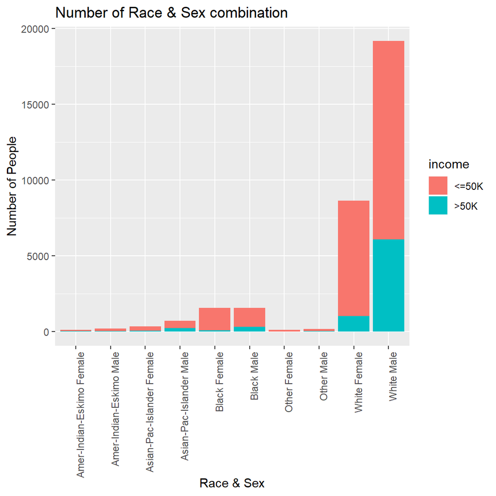

```r
ggplot(Q1_2,aes(x=race_sex_combine, y =num_rows, fill = income))+
  geom_bar(stat = 'identity')+
  theme(axis.text.x = element_text(angle = 90, hjust = 1))+
  ggtitle('Number of Race & Sex combination')+
  xlab("Race & Sex")+
  ylab("Number of People")
```

## In conclusion

White Male most represented in this data set, Other Female is least likely to make more than $50K.

# Question 3

What steps did you take to prepare the data for your analysis and why did you need to do those steps? What tools did you use to do this data preparation and the associated analyses?

## Clean the Missing value

I replaced the data with NA for the string “?”when I imported the dataset to make the treatment of missing values easier.

```r
table(complete.cases(raw))
```

```
##
## FALSE  TRUE
##  2399 30162
```

```r
summary(raw[!complete.cases(raw),])
```

```
##       age                   workclass        fnlwgt
##  Min.   :17.00   Private         : 410   Min.   : 12285
##  1st Qu.:22.00   Self-emp-inc    :  42   1st Qu.:121804
##  Median :36.00   Self-emp-not-inc:  42   Median :177906
##  Mean   :40.39   Local-gov       :  26   Mean   :189584
##  3rd Qu.:58.00   State-gov       :  19   3rd Qu.:232669
##  Max.   :90.00   (Other)         :  24   Max.   :981628
##                  NA's            :1836
##         education    educationnum                 maritalstatus
##  HS-grad     :661   Min.   : 1.00   Divorced             :229
##  Some-college:613   1st Qu.: 9.00   Married-AF-spouse    :  2
##  Bachelors   :311   Median :10.00   Married-civ-spouse   :911
##  11th        :127   Mean   : 9.57   Married-spouse-absent: 48
##  10th        :113   3rd Qu.:11.00   Never-married        :957
##  Masters     : 96   Max.   :16.00   Separated            : 86
##  (Other)     :478                   Widowed              :166
##            occupation           relationship                 race
##  Prof-specialty : 102   Husband       :730   Amer-Indian-Eskimo:  25
##  Other-service  :  83   Not-in-family :579   Asian-Pac-Islander: 144
##  Exec-managerial:  74   Other-relative: 92   Black             : 307
##  Craft-repair   :  69   Own-child     :602   Other             :  40
##  Sales          :  66   Unmarried     :234   White             :1883
##  (Other)        : 162   Wife          :162
##  NA's           :1843
##      sex        capitalgain       capitalloss       hoursperweek
##  Female: 989   Min.   :    0.0   Min.   :   0.00   Min.   : 1.00
##  Male  :1410   1st Qu.:    0.0   1st Qu.:   0.00   1st Qu.:25.00
##                Median :    0.0   Median :   0.00   Median :40.00
##                Mean   :  897.1   Mean   :  73.87   Mean   :34.23
##                3rd Qu.:    0.0   3rd Qu.:   0.00   3rd Qu.:40.00
##                Max.   :99999.0   Max.   :4356.00   Max.   :99.00
##
##        nativecountry    income
##  United-States:1666   <=50K:2066
##  Mexico       :  33   >50K : 333
##  Canada       :  14
##  Philippines  :  10
##  Germany      :   9
##  (Other)      :  84
##  NA's         : 583
```

```r
summary(raw)
```

```
##       age                   workclass         fnlwgt
##  Min.   :17.00   Private         :22696   Min.   :  12285
##  1st Qu.:28.00   Self-emp-not-inc: 2541   1st Qu.: 117827
##  Median :37.00   Local-gov       : 2093   Median : 178356
##  Mean   :38.58   State-gov       : 1298   Mean   : 189778
##  3rd Qu.:48.00   Self-emp-inc    : 1116   3rd Qu.: 237051
##  Max.   :90.00   (Other)         :  981   Max.   :1484705
##                  NA's            : 1836
##         education      educationnum                 maritalstatus
##  HS-grad     :10501   Min.   : 1.00   Divorced             : 4443
##  Some-college: 7291   1st Qu.: 9.00   Married-AF-spouse    :   23
##  Bachelors   : 5355   Median :10.00   Married-civ-spouse   :14976
##  Masters     : 1723   Mean   :10.08   Married-spouse-absent:  418
##  Assoc-voc   : 1382   3rd Qu.:12.00   Never-married        :10683
##  11th        : 1175   Max.   :16.00   Separated            : 1025
##  (Other)     : 5134                   Widowed              :  993
##            occupation            relationship                   race
##  Prof-specialty : 4140   Husband       :13193   Amer-Indian-Eskimo:  311
##  Craft-repair   : 4099   Not-in-family : 8305   Asian-Pac-Islander: 1039
##  Exec-managerial: 4066   Other-relative:  981   Black             : 3124
##  Adm-clerical   : 3770   Own-child     : 5068   Other             :  271
##  Sales          : 3650   Unmarried     : 3446   White             :27816
##  (Other)        :10993   Wife          : 1568
##  NA's           : 1843
##      sex         capitalgain     capitalloss      hoursperweek
##  Female:10771   Min.   :    0   Min.   :   0.0   Min.   : 1.00
##  Male  :21790   1st Qu.:    0   1st Qu.:   0.0   1st Qu.:40.00
##                 Median :    0   Median :   0.0   Median :40.00
##                 Mean   : 1078   Mean   :  87.3   Mean   :40.44
##                 3rd Qu.:    0   3rd Qu.:   0.0   3rd Qu.:45.00
##                 Max.   :99999   Max.   :4356.0   Max.   :99.00
##
##        nativecountry     income
##  United-States:29170   <=50K:24720
##  Mexico       :  643   >50K : 7841
##  Philippines  :  198
##  Germany      :  137
##  Canada       :  121
##  (Other)      : 1709
##  NA's         :  583
```

From the summary, 2399 datapoints are NA, which is 7.3% of the dataset.

In income columns, we find that 2066 of 2399 NA are in < 50K. Because most of the dataset are < 50K(24720/32562), so removing this NA rows won’t influence the result.

```r
clean <- na.omit(raw)
```

```r
str(clean)
```

```
## 'data.frame':    30162 obs. of  15 variables:
##  $ age          : int  39 50 38 53 28 37 49 52 31 42 ...
##  $ workclass    : Factor w/ 8 levels "Federal-gov",..: 7 6 4 4 4 4 4 6 4 4 ...
##  $ fnlwgt       : int  77516 83311 215646 234721 338409 284582 160187 209642 45781 159449 ...
##  $ education    : Factor w/ 16 levels "10th","11th",..: 10 10 12 2 10 13 7 12 13 10 ...
##  $ educationnum : int  13 13 9 7 13 14 5 9 14 13 ...
##  $ maritalstatus: Factor w/ 7 levels "Divorced","Married-AF-spouse",..: 5 3 1 3 3 3 4 3 5 3 ...
##  $ occupation   : Factor w/ 14 levels "Adm-clerical",..: 1 4 6 6 10 4 8 4 10 4 ...
##  $ relationship : Factor w/ 6 levels "Husband","Not-in-family",..: 2 1 2 1 6 6 2 1 2 1 ...
##  $ race         : Factor w/ 5 levels "Amer-Indian-Eskimo",..: 5 5 5 3 3 5 3 5 5 5 ...
##  $ sex          : Factor w/ 2 levels "Female","Male": 2 2 2 2 1 1 1 2 1 2 ...
##  $ capitalgain  : int  2174 0 0 0 0 0 0 0 14084 5178 ...
##  $ capitalloss  : int  0 0 0 0 0 0 0 0 0 0 ...
##  $ hoursperweek : int  40 13 40 40 40 40 16 45 50 40 ...
##  $ nativecountry: Factor w/ 41 levels "Cambodia","Canada",..: 39 39 39 39 5 39 23 39 39 39 ...
##  $ income       : Factor w/ 2 levels "<=50K",">50K": 1 1 1 1 1 1 1 2 2 2 ...
##  - attr(*, "na.action")= 'omit' Named int  15 28 39 52 62 70 78 94 107 129 ...
##   ..- attr(*, "names")= chr  "15" "28" "39" "52" ...
```

## Correlation plot

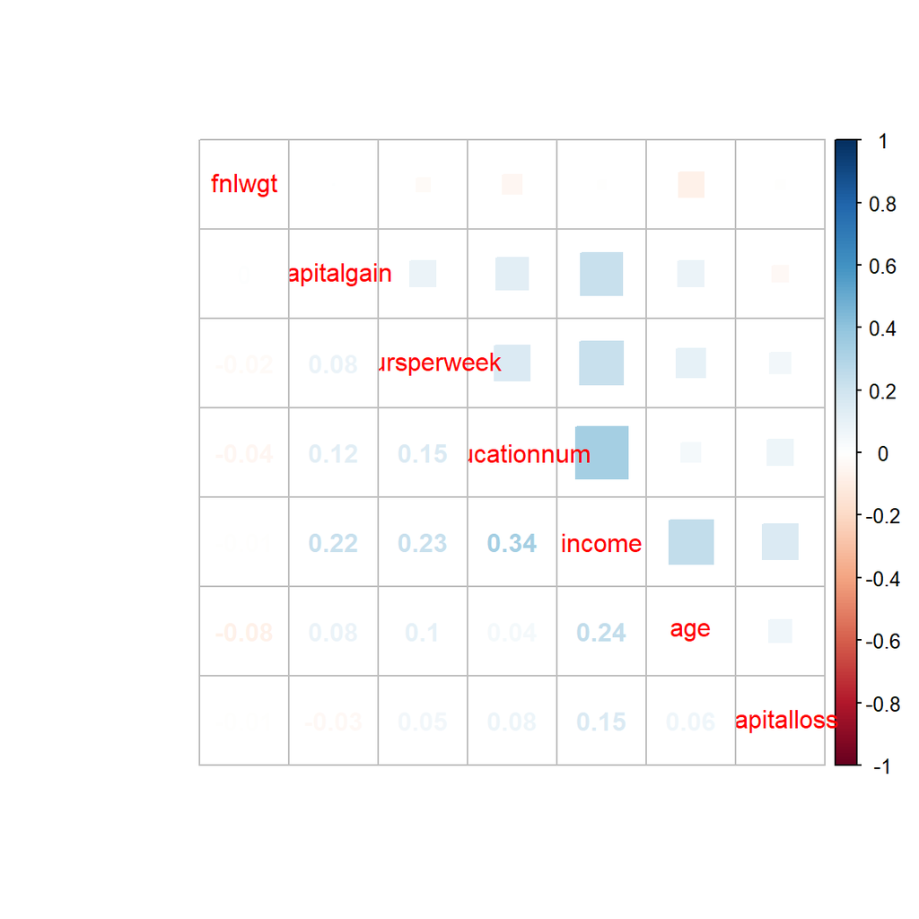

```r
#Changing income to 0, 1
clean$income <- as.numeric(clean$income)-1
#Correlation plot
num.var <- c(1, 3, 5, 11:13, 15)

corrplot::corrplot.mixed(cor(clean[,num.var]), lower = "number", upper = "square", order = "hclust")
```

I built a correlation plot to see whether there is any relationshi between the numeric and the income. First, I change the income to 0 and 1 to make it numeric. From the plot, we can see there is no variable strongly related with each other.

```r
#Re-factoring income
clean$income <- factor(clean$income, labels=c("<=50k", ">50k"))
levels(clean$income)
```

```
## [1] "<=50k" ">50k"
```

## In conclusion

During the data preparation process, first, I replace the ? to NA for the convenience of cleaning data. Then, I count the row of number which contains NA and see whether the proportion of NA will influence data integrity.Finally, I removed all the NA because most of the rows including NA centres around <=50k category, which will not affect the results.

For associated analysses, I built correlation plot to see the relationship between variables. I extract all the numeric variables and convert income results to numeric 0 and 1. It turns out that there is no obvious relationship between variables.

# Question 2

Are there any columns that can be dropped from this data set without damaging the information contained within the data?

## Captain gain VS Captain loss

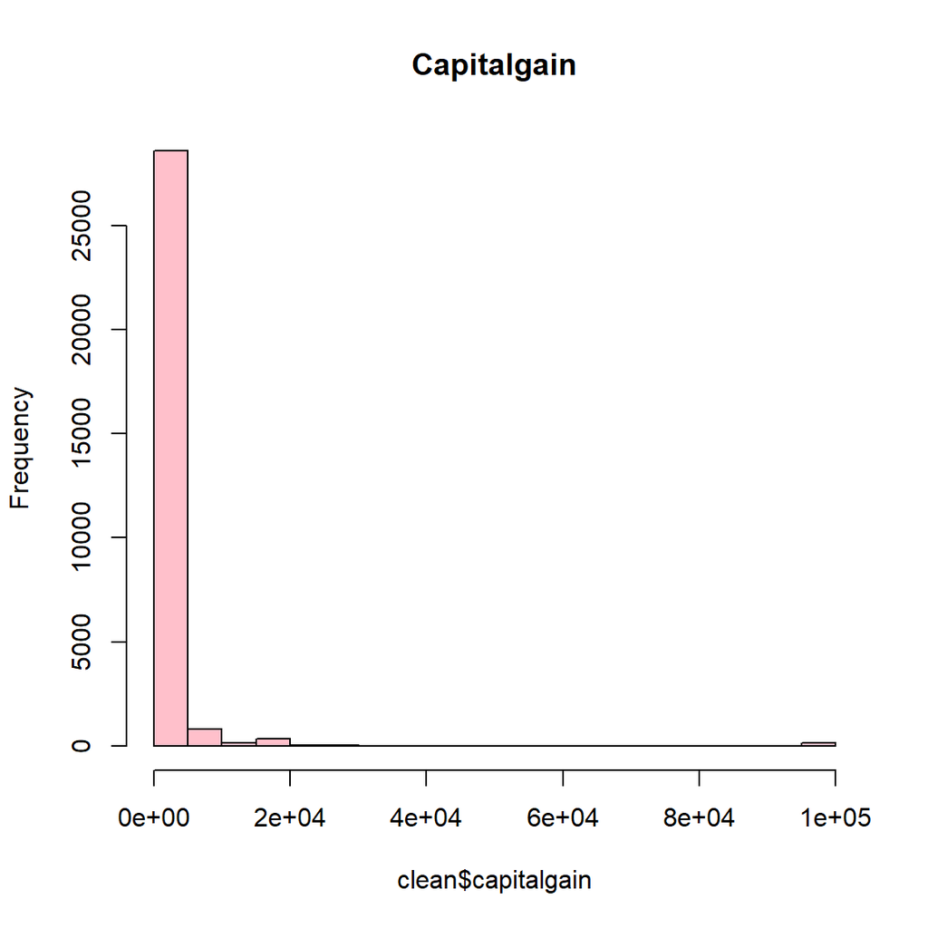

```r
hist(clean$capitalgain, col="pink", main="Capitalgain")
```

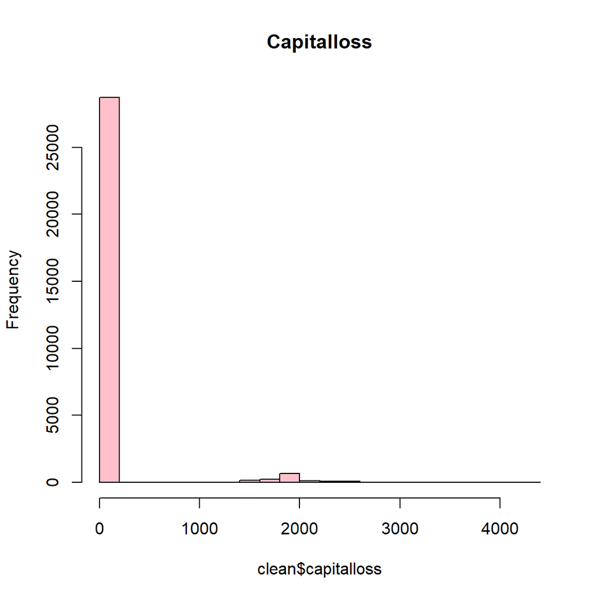

```r
hist(clean$capitalloss, col="pink", main="Capitalloss")
```

```r
# check whether who have both captial loss and gain
sum(clean$capitalloss > 0 & clean$capitalgain > 0)
```

```
## [1] 0
```

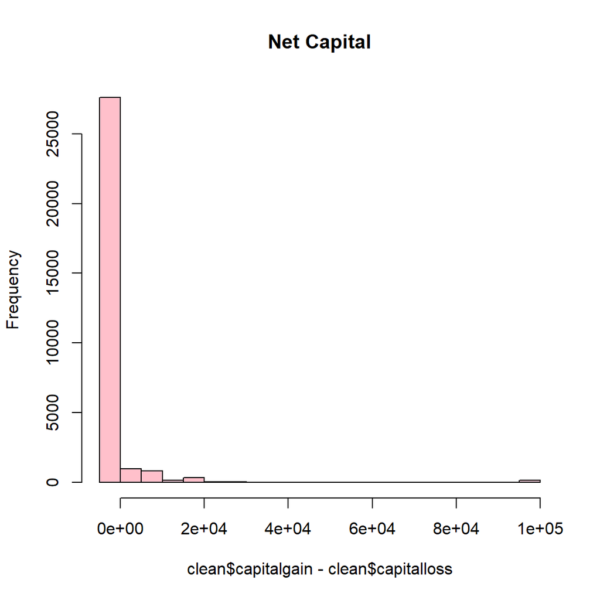

```r
#Net Capital = Capitalgain - Capitalloss
hist(clean$capitalgain-clean$capitalloss, col="pink", main="Net Capital")
```

From the plot above, there is no one who has both capitalgain and capitalloss, so I will drop off both columns and combine them to a new column “netapital”, which is more convenient for building the model.

```r
clean$netcapital <- clean$capitalgain-clean$capitalloss
```

## Education vs Educationnum

```r
# levels of education
levels(clean$education)
```

```
##  [1] "10th"         "11th"         "12th"         "1st-4th"
##  [5] "5th-6th"      "7th-8th"      "9th"          "Assoc-acdm"
##  [9] "Assoc-voc"    "Bachelors"    "Doctorate"    "HS-grad"
## [13] "Masters"      "Preschool"    "Prof-school"  "Some-college"
```

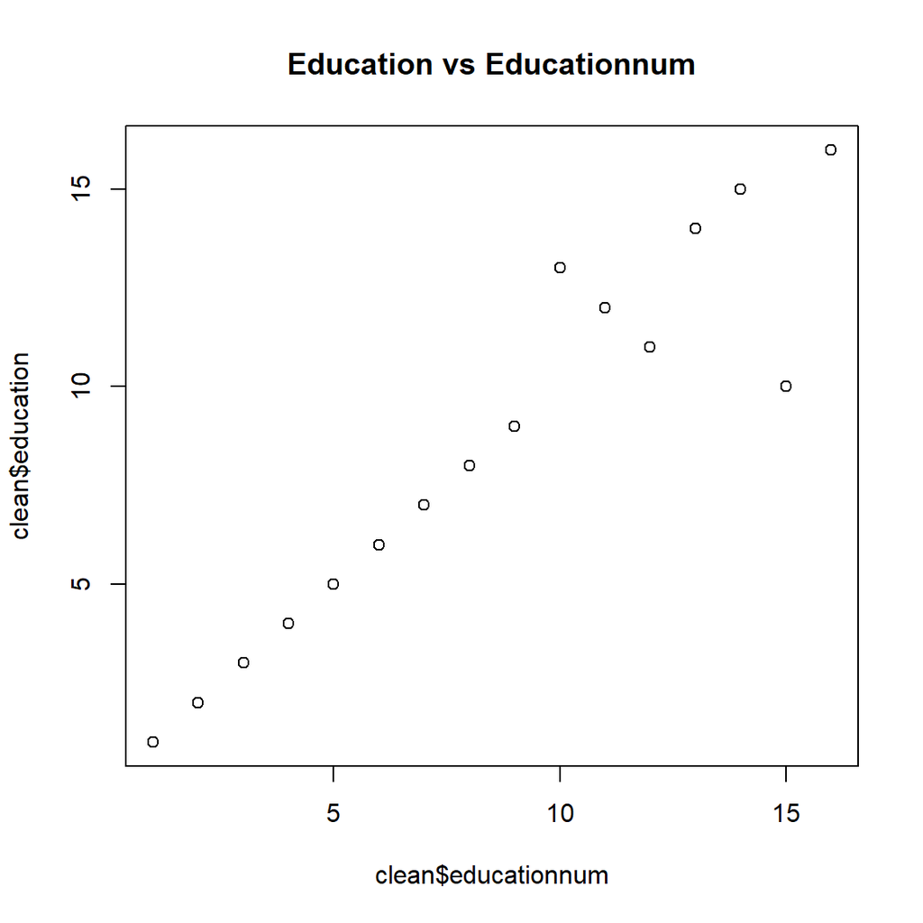

```r
#reorder the education first
clean$education <- factor(clean$education,levels(clean$education)[c(14, 4:7, 1:3, 12, 15, 8:9, 16, 10, 13, 11)])

plot(clean$educationnum,clean$education,main="Education vs Educationnum")
```

## Nativecountry

```r
nativedata <- data.frame(ddply(clean,.(nativecountry),nrow))
nativedata%>%
  arrange(desc(V1))
```

```
##                 nativecountry    V1
## 1               United-States 27504
## 2                      Mexico   610
## 3                 Philippines   188
## 4                     Germany   128
## 5                 Puerto-Rico   109
## 6                      Canada   107
## 7                 El-Salvador   100
## 8                       India   100
## 9                        Cuba    92
## 10                    England    86
## 11                    Jamaica    80
## 12                      South    71
## 13                      China    68
## 14                      Italy    68
```

[output cut: 27 more lines]

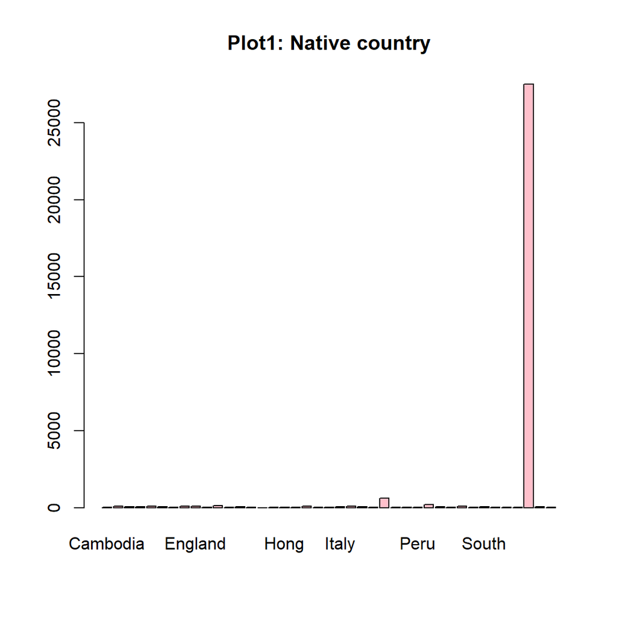

```r
plot(clean$nativecountry,col = 'pink', main="Plot1: Native country")
```

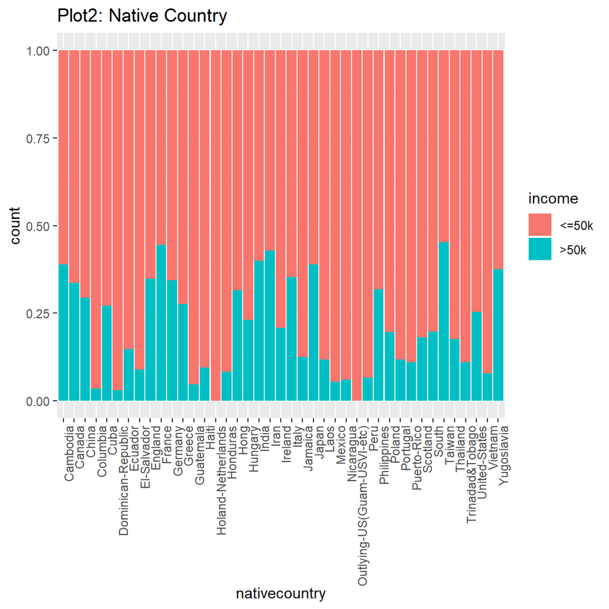

```r
ggplot(clean,aes(x = nativecountry, fill = income)) + geom_bar(position="fill") + theme(axis.text.x = element_text(angle = 90, hjust = 1)) + ggtitle("Plot2: Native Country")
```

From the table and plot 1, we can see USA dominated in all the native country (27504/30162), but from plot 2 there is no clear relationship between income and the native country. So, I will also drop off the native country column.

## In conclusion

```r
clean2 <- clean%>%
  select(-educationnum,-capitalgain,-capitalloss,-nativecountry)
```

From the analysis above, I drop educationnum, capitalgain, capitalloss, nativecountry 4 columns which will not damage the information contained within the data. At the same time, I set up a new column Netcapital to combine capitalgain and capitalloss together for the convenience of building the model.

# Question 4

The column “fnlwgt” is a continuous variable that has a complicated, interconnected definition. For this column is a higher value or a lower value more likely to predict high income?

## logistic regression

```r
fniwgtdf <- clean2%>%
  dplyr::select(fnlwgt,income)
fniwgtfit <- glm(income~., family=binomial(link='logit'),data = fniwgtdf)
summary(fniwgtfit)
```

```
##
## Call:
## glm(formula = income ~ ., family = binomial(link = "logit"),
##     data = fniwgtdf)
##
## Deviance Residuals:
##     Min       1Q   Median       3Q      Max
## -0.7681  -0.7598  -0.7552  -0.7212   1.7598
##
## Coefficients:
##               Estimate Std. Error z value Pr(>|z|)
## (Intercept) -1.067e+00  2.742e-02 -38.910   <2e-16 ***
## fnlwgt      -1.976e-07  1.270e-07  -1.556     0.12
## ---
## Signif. codes:  0 '***' 0.001 '**' 0.01 '*' 0.05 '.' 0.1 ' ' 1
##
## (Dispersion parameter for binomial family taken to be 1)
##
##     Null deviance: 33851  on 30161  degrees of freedom
## Residual deviance: 33848  on 30160  degrees of freedom
## AIC: 33852
##
## Number of Fisher Scoring iterations: 4
```

From the summary, we can see AIC = 33852,which means Information lost is really huge. From the p-value = 0.12, this model is not significant, which we can assume that this model cannot be built.

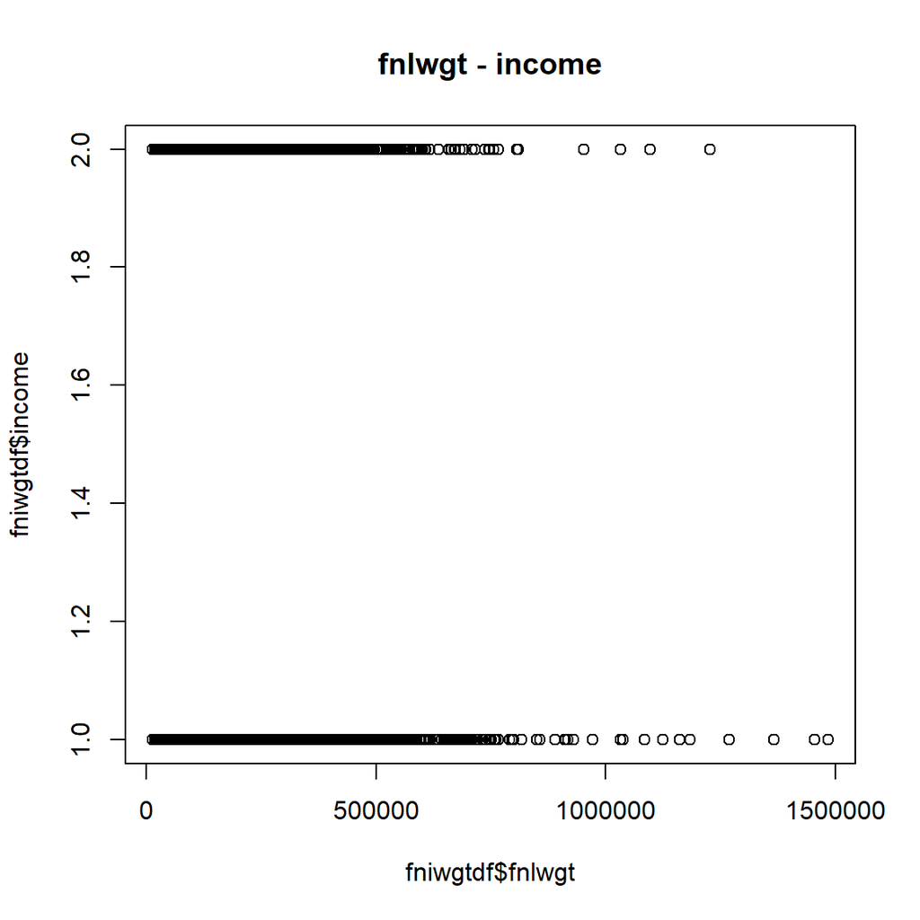

```r
plot(fniwgtdf$fnlwgt,fniwgtdf$income,main="fnlwgt - income")
```

```
## Warning: glm.fit: algorithm did not converge
```

```
## Warning: Computation failed in `stat_smooth()`:
## y values must be 0 <= y <= 1
```

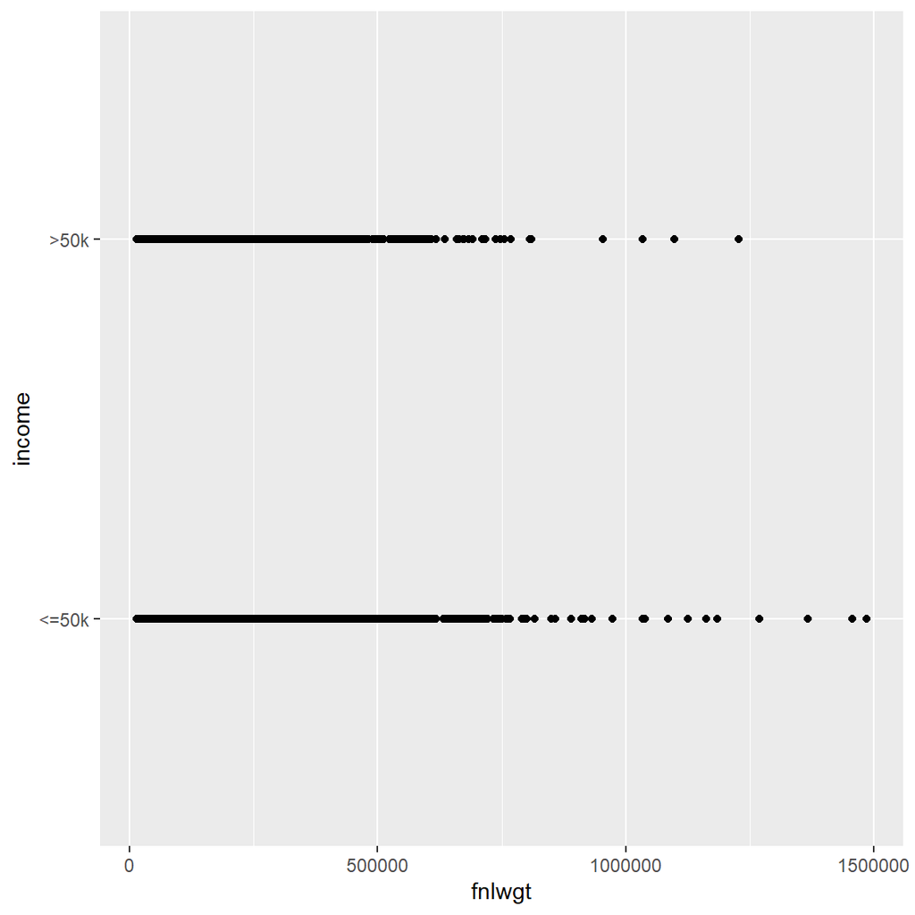

```r
# try to build curve in logistic regression model
ggplot(fniwgtfit, aes(x=fnlwgt, y=income)) + geom_point() +
  stat_smooth(method="glm", method.args=list(family="binomial"), se=FALSE)
```

From the first plot, we can generally know from this data distribution that we cannot built logistic regression and the variable fnlwgt - income don’t have clear relationship. Then I try to build sigmod curve in logistic regression, but the system warns me it doesn’t work.

## In conclusion

In conclusion, fnlwgt don’t have obvious relationship with income, so we cannot fnlwgt whether it is a higher value or a lower value more likely to predict high income.

# Question 5

If we could only have access to one of the columns (not the target column) and still needed to make an income prediction, which column would you choose and why? What if you could have access to 3 columns?

## Decision Tree

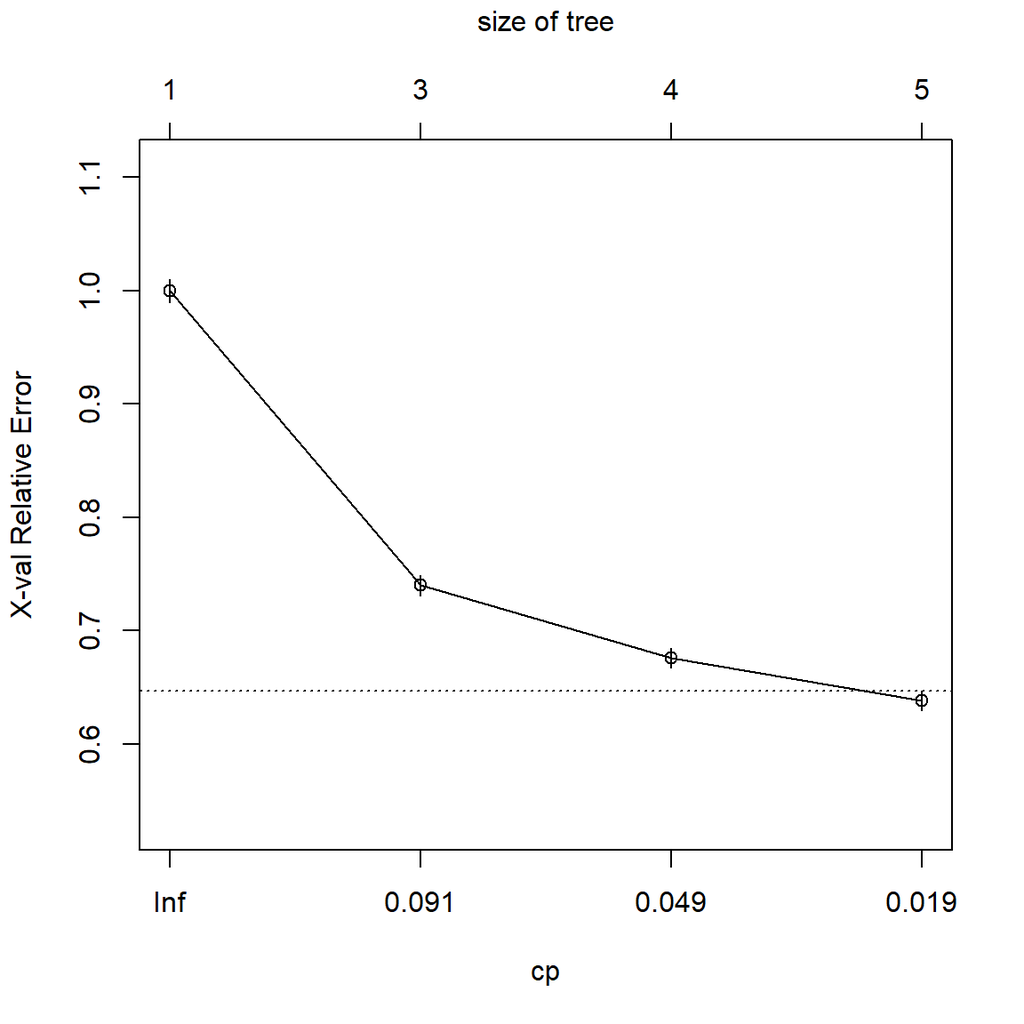

```r
tree <- rpart(income ~ .,
              data = clean2,
              method = "class")
plotcp(tree)
```

To see which variable plays a more critical role to predict income, decision tree is the best way.

From the cpplot, when tree size = 5,the relative error reaches to the lowest.

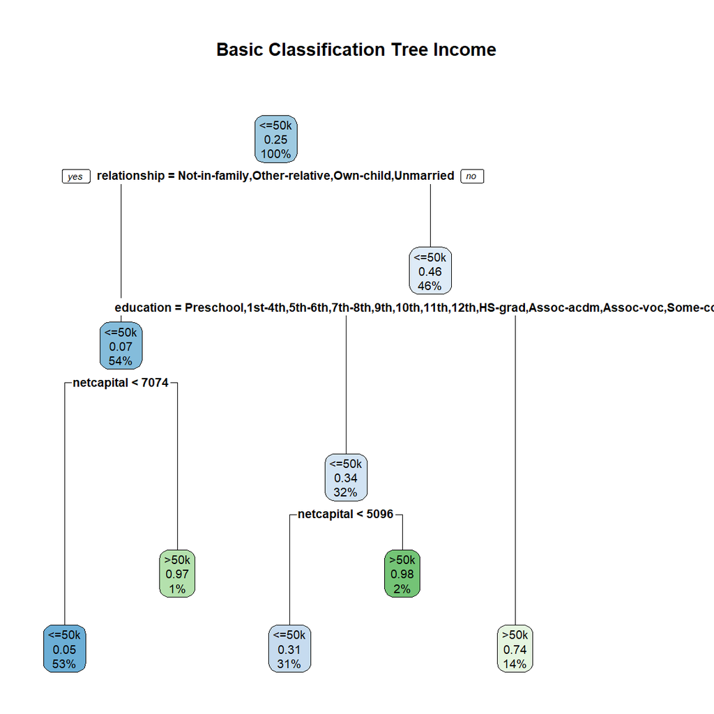

```r
# Tree plot
rpart.plot(tree, main = "Basic Classification Tree Income")
```

```r
tree
```

```
## n= 30162
##
## node), split, n, loss, yval, (yprob)
##       * denotes terminal node
##
##  1) root 30162 7508 <=50k (0.75107751 0.24892249)
##    2) relationship=Not-in-family,Other-relative,Own-child,Unmarried 16293 1135 <=50k (0.93033818 0.06966182)
##      4) netcapital< 7073.5 15993  845 <=50k (0.94716438 0.05283562) *
##      5) netcapital>=7073.5 300   10 >50k (0.03333333 0.96666667) *
##    3) relationship=Husband,Wife 13869 6373 <=50k (0.54048598 0.45951402)
##      6) education=Preschool,1st-4th,5th-6th,7th-8th,9th,10th,11th,12th,HS-grad,Assoc-acdm,Assoc-voc,Some-college 9719 3322 <=50k (0.65819529 0.34180471)
##       12) netcapital< 5095.5 9219 2831 <=50k (0.69291680 0.30708320) *
##       13) netcapital>=5095.5 500    9 >50k (0.01800000 0.98200000) *
##      7) education=Prof-school,Bachelors,Masters,Doctorate 4150 1099 >50k (0.26481928 0.73518072) *
```

```r
imp <- varImp(tree)
imp
```

```
##                  Overall
## age            419.62122
## education     2401.25708
## hoursperweek   294.47722
## maritalstatus 2244.51305
## netcapital    3163.39712
## occupation    2236.52989
## relationship  2277.27804
## workclass       82.19351
## fnlwgt           0.00000
## race             0.00000
## sex              0.00000
```

```r
rownames(imp)[order(imp$Overall, decreasing=TRUE)]
```

```
##  [1] "netcapital"    "education"     "relationship"  "maritalstatus"
##  [5] "occupation"    "age"           "hoursperweek"  "workclass"
##  [9] "fnlwgt"        "race"          "sex"
```

From the treeplot ,we can see that only “Netcapital”,“Education”, “Relationship” three variables are used in the Decision tree method.

From the table, Netcapital is the top key predictors followed by education and relationship for predicting the income levels.

## In conclusion

# Question 6

What level of education should you achieve if you want to have a better than 50% chance of making more than $50K (per this data set)?

```r
educatipntree <- clean2%>%
  dplyr::select(education,income)

edutree <- rpart(income ~ .,
              data = educatipntree,
              method = "class")
```

```r
edutree
```

```
## n= 30162
##
## node), split, n, loss, yval, (yprob)
##       * denotes terminal node
##
## 1) root 30162 7508 <=50k (0.7510775 0.2489225)
##   2) education=Preschool,1st-4th,5th-6th,7th-8th,9th,10th,11th,12th,HS-grad,Assoc-acdm,Assoc-voc,Some-college 22574 3778 <=50k (0.8326393 0.1673607) *
##   3) education=Prof-school,Bachelors,Masters,Doctorate 7588 3730 <=50k (0.5084344 0.4915656)
##     6) education=Bachelors 5044 2126 <=50k (0.5785091 0.4214909) *
##     7) education=Prof-school,Masters,Doctorate 2544  940 >50k (0.3694969 0.6305031) *
```

To see which level of education will have better than 50% chance of making more than $50K, we can directly see the nodes of tree. First, I select education and Income to build a new dataframe and build a decision tree model for them. Then, I print out all the nodes to see the probability of each education level. From the text above, only education = Prof-school,Masters,Doctorate 2544 940 >50k (0.3694969 0.6305031) have better than 50% chance.

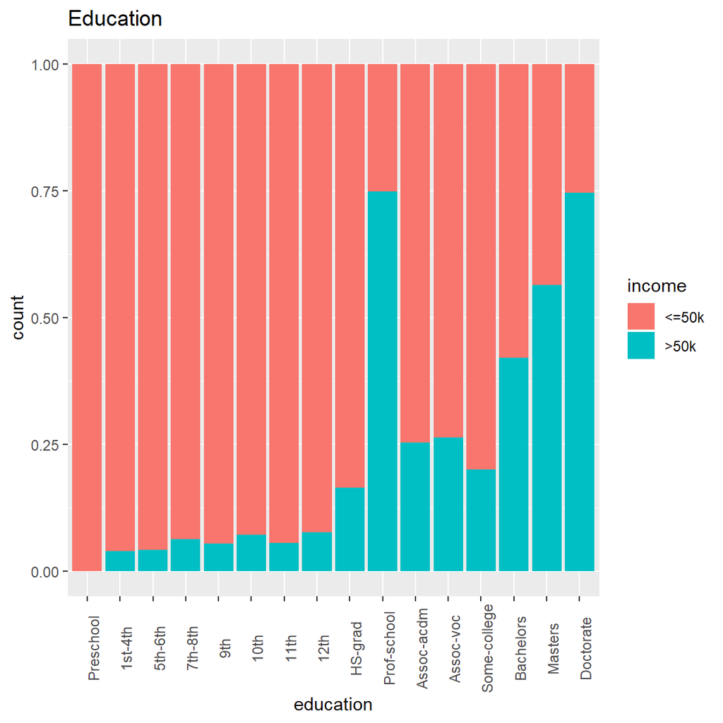

```r
ggplot(educatipntree, aes(x = education, fill = income)) + geom_bar(position="fill") + theme(axis.text.x = element_text(angle = 90)) + ggtitle("Education")
```

At the same time, I also plot a bar chart to see the relationship between education level and the income. We can know the bar of >50k in Prof-school, masters, doctorate higher than 0.5, which prove the previous findings.

## In conclusion

People who achieve Prof-school, masters, doctorate have a better than 50% chance of making more than $50K.